# Ejemplo simple con stan

2/25/2021

https://betanalpha.github.io/assets/case_studies/principled_bayesian_workflow.html

## Preparación

```r
devtools::install_github("cotecora-team-2/quickcountmx")
library(cmdstanr)
library(posterior)
library(tidyverse)
library(patchwork)
theme_set(theme_minimal())
cb_palette <- c("#000000", "#E69F00", "#56B4E9", "#009E73",
                "#F0E442", "#0072B2", "#D55E00", "#CC79A7")
```

### Problema

Queremos modelar la estatura de tenores y bajos de un coro, y queremos saber si sus estaturas son diferentes.

### Análisis conceptual

Supondremos que tenemos una muestra seleccionada al azar de medidas de estaturas de tenores y de bajos de un coro particular. No tenemos covariables adicionales. Las estaturas están redondeadas a pulgadas. Las distintas tesituras pueden requerir distintas formas de cuerpo, lo cual es posible que se refleje en las estaturas.

### Espacio de observaciones

Las únicas observaciones que esperamos son una lista de $n_1$ estaturas en pulgadas de tenores y $n_2$ estaturas de bajos. En el modelo podemos escribirlo con dos vectores separados (alternativamente, un solo vector con identificadores)

```bash
sed -n '/^data/,/\}/p' ./stan/modelo.stan
```

```
## data {
##   int<lower=0> n_1;
##   int<lower=0> n_2;
##   vector[n_1] y_1;
##   vector[n_2] y_2;
##   real media_params[2];
##   real sd_params;
## }
```

### Estadísticas resumen

Las estadísticas resumen que nos interesan son los valores esperados de:

- La diferencia de medias entre los grupos
- Probabilidad posterior de que la media de un grupo sea mayor que la otra

```bash
sed -n '/^transformed/,/\}/p' ./stan/modelo.stan
```

```
## transformed parameters {
##   real dif;
##   real mayor_1;
##
##   dif = mu[1] - mu[2];
##   mayor_1 = mu[1] > mu[2];
## }
```

### Desarrollo del modelo

En este caso simple, modelamos cada muestra con una distribución normal, cada una con parámetros a priori independientes. La versimilitud se construye como:

$$y_{1,i} \sim N(\mu_1, \sigma_1), y_{2, j} \sim N(\mu_2, \sigma_2)$$
donde las $y_{g,i}$ son todas independientes dados los parámetros respectivos. Ahora tenemos que establecer las distribuciones iniciales con la información disponible. Por el momento no tenemos información de que haya alguna diferencia entre los grupos de cantantes, así que pondremos la misma inicial para medias y desviaciones estándar.

Para las medias, usaremos una distribución que vaya de unos 1.60 a 1.80m (son cantantes adultos de un coro):

$$\mu_i \sim N(170, 5)$$
Los cuantiles de esta distribución son

```r
quantile(rnorm(1000, 170, 5), probs = c(0.05, 0.5, 0.95))
```

```
##       5%      50%      95%
## 161.8048 170.0993 178.6769
```

¿Qué sabemos acerca de la dispersión de las estaturas de un grupo de cantantes (hombres)? Dada una media (por ejemplo 170), no debería ser extremadamente sorprendente observar estaturas de 150 o de 190. Sería poco probable observar, por ejemplo variaciones más chicas de más menos dos centímetros de la media.

$$\sigma_i \sim N^+(0, 6)$$
Si simulamos 2 veces la desviación estándar ($2\sigma_i$):

```r
quantile(2 + 2 * abs(rnorm(1000, 0, 6)), probs = c(0.05, 0.5, 0.95))
```

```
##        5%       50%       95%
##  2.637452 10.384768 25.353497
```

### Simular ensamble bayesiano

```r
sim_datos <- jsonlite::read_json("./datos/datos_prueba.json", simplifyVector = TRUE)
parametros <- jsonlite::read_json("./datos/datos_inicial.json", simplifyVector = TRUE)
print(parametros)
```

```
## $media_params
## [1] 170   5
##
## $sd_params
## [1] 6
```

```r
print(sim_datos)
```

```
## $n_1
## [1] 20
##
## $n_2
## [1] 10
```

```r
sim_ensemble_datos <- c(sim_datos, parametros)
ruta <- file.path("./stan/simular_ensemble_modelo.stan")
modelo_inicial <- cmdstan_model(ruta)
```

```
## Model executable is up to date!
```

```r
ensemble <- modelo_inicial$sample(
    data = sim_ensemble_datos,
    iter_sampling = 100, iter_warmup = 0,
    chains = 1,
    refresh = 10, seed = 4322,
    fixed_param = TRUE)
```

```
## Running MCMC with 1 chain...
##
## Chain 1 Iteration:  1 / 100 [  1%]  (Sampling)
## Chain 1 Iteration: 10 / 100 [ 10%]  (Sampling)
## Chain 1 Iteration: 20 / 100 [ 20%]  (Sampling)
## Chain 1 Iteration: 30 / 100 [ 30%]  (Sampling)
## Chain 1 Iteration: 40 / 100 [ 40%]  (Sampling)
## Chain 1 Iteration: 50 / 100 [ 50%]  (Sampling)
## Chain 1 Iteration: 60 / 100 [ 60%]  (Sampling)
## Chain 1 Iteration: 70 / 100 [ 70%]  (Sampling)
## Chain 1 Iteration: 80 / 100 [ 80%]  (Sampling)
## Chain 1 Iteration: 90 / 100 [ 90%]  (Sampling)
## Chain 1 Iteration: 100 / 100 [100%]  (Sampling)
## Chain 1 finished in 0.0 seconds.
```

Ahora examinamos el ensamble. Por ejemplo, para una simulación:

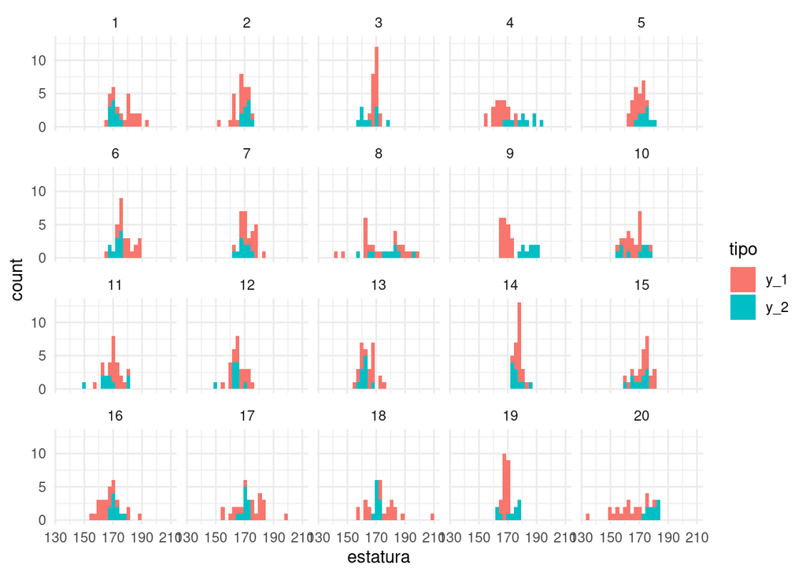

```r
source("R/resumenes.R")
histogramas_estaturas(ensemble, sim_ensemble_datos, k = 20)
```

Aunque los rangos parecen correctos,

- En algunos casos la dispersión es muy baja.
- Es poco creíble que la dispersión sea radicalmente distinta en cada uno de los grupos

Estos defectos deben ser arreglados en el modelo + información inicial.

### Ajustar al ensemble simulado

Ahora probamos ajustar el modelo a las simulaciones. En este paso tenemos qué checar qué puede pasar incluso con las condiciones más extremas que creemos que podemos encontrar.

Podemos probar con una simulación:

```r
num_iter <- 11
y_sim <- ensemble$draws(c("y_1_sim", "y_2_sim"))
sigma_sim_tbl <- ensemble$draws(c("mu", "sigma")) %>% as_draws_df()
```

```r
ruta <- file.path("./stan/modelo.stan")
modelo <- cmdstan_model(ruta)
```

```
## Model executable is up to date!
```

```r
datos_1 <- c(sim_ensemble_datos, list("y_1" = y_sim[num_iter, , 1:20] %>% as.numeric,
                                      "y_2" = y_sim[num_iter, , 21:30] %>% as.numeric()))
ajuste <- modelo$sample(data = datos_1,
                          seed = 2210,
                          iter_sampling = 1000, iter_warmup = 1000,
                          refresh = 0,
                          show_messages = FALSE)
```

```
## Running MCMC with 4 sequential chains...
##
## Chain 1 finished in 0.0 seconds.
## Chain 2 finished in 0.0 seconds.
## Chain 3 finished in 0.0 seconds.
## Chain 4 finished in 0.1 seconds.
##
## All 4 chains finished successfully.
## Mean chain execution time: 0.0 seconds.
## Total execution time: 0.5 seconds.
```

```r
ajuste
```

```
##  variable   mean median   sd  mad     q5    q95 rhat ess_bulk ess_tail
##  lp__     -69.63 -69.31 1.36 1.21 -72.21 -68.01 1.00     2274     2870
##  mu[1]    170.56 170.57 1.19 1.19 168.60 172.54 1.00     4348     3032
##  mu[2]    168.05 168.08 2.50 2.42 163.93 172.26 1.00     3682     2812
##  sigma[1]   3.57   3.46 0.91 0.86   2.30   5.25 1.00     3861     2715
##  sigma[2]   7.39   7.10 1.99 1.83   4.71  11.08 1.00     3854     3169
##  dif        2.52   2.52 2.76 2.75  -2.16   7.00 1.00     3846     2891
##  mayor_1    0.82   1.00 0.38 0.00   0.00   1.00 1.00     3295       NA
```

```r
ajuste$cmdstan_diagnose()
```

```
## Running bin/diagnose /tmp/Rtmp2zsdkf/modelo-202102262305-1-836db5.csv \
##   /tmp/Rtmp2zsdkf/modelo-202102262305-2-836db5.csv \
##   /tmp/Rtmp2zsdkf/modelo-202102262305-3-836db5.csv \
##   /tmp/Rtmp2zsdkf/modelo-202102262305-4-836db5.csv
## Processing csv files: /tmp/Rtmp2zsdkf/modelo-202102262305-1-836db5.csv, /tmp/Rtmp2zsdkf/modelo-202102262305-2-836db5.csv, /tmp/Rtmp2zsdkf/modelo-202102262305-3-836db5.csv, /tmp/Rtmp2zsdkf/modelo-202102262305-4-836db5.csv
##
## Checking sampler transitions treedepth.
## Treedepth satisfactory for all transitions.
##
## Checking sampler transitions for divergences.
## No divergent transitions found.
##
## Checking E-BFMI - sampler transitions HMC potential energy.
## E-BFMI satisfactory for all transitions.
##
## Effective sample size satisfactory.
##
## Split R-hat values satisfactory all parameters.
##
## Processing complete, no problems detected.
```

No detectamos ningún problema. Si detectamos problemas numéricos, podemos ajustar en orden de dificultad y costo típico: 1) parámetros del muestreador, 2) modelo, 3) diseño de recolección de datos

### Calibración algorítmica

Ahora checamos si recuperamos los parámetros de las simulaciones:

```r
param_sim_tbl <- ensemble$draws(c("mu[1]", "sigma[1]")) %>% as_draws_df()
```

En algunas corridas obtuvimos problemas numéricos:

```r
map(ajustes_ensemble$diagnosticos, "stdout") %>% str_detect("no problems detected") %>%
  table
```

```
## .
## FALSE  TRUE
##     1    99
```

Ahora checamos que recuperamos los parámetros apropiadamente:

```r
sbc_rank_sim <- ajustes_ensemble %>% select(sbc_rank) %>% unnest
```

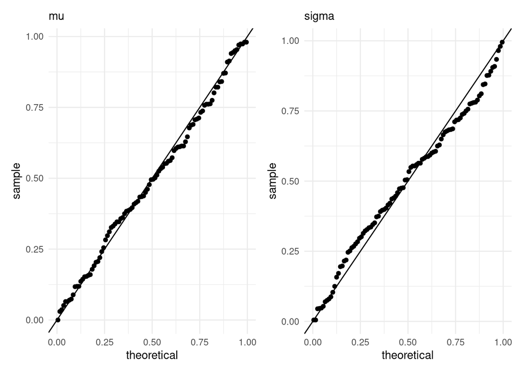

```r
g_mu <- ggplot(sbc_rank_sim, aes(sample = `mu[1]`)) +
  geom_qq(distribution = stats::qunif) +
  geom_abline() +
  labs(subtitle = "mu")
g_sigma <- ggplot(sbc_rank_sim, aes(sample = `sigma[1]`)) +
  geom_qq(distribution = stats::qunif) +
  geom_abline() +
  labs(subtitle = "sigma")
g_mu + g_sigma
```

### Calibración inferencial

En el siguiente paso vemos las posibilidades de aprendizaje que nos da el modelo. En este punto, quisiéramos saber si aprendemos algo por encima de lo que ya sabíamos.

- Esto se mide con la **contracción**: cómo se compara la incertidumbre a priori con la posterior. Si la contracción es baja, el modelo está mal identificado o mal especificado. Comparamos las medias posteriores con el verdadero valor para diagnosticar si es solo mala identificación (estas dos medias son similares), o mal espcificación (están concentradas en lugares diferentes)
- Cuando la contracción es alta, quiere decir que aprendemos del parámetro de interés. Sin embargo, si las posteriores varían mucho en dónde están concentradas en comparación a los verdaderos valores, esto indica sobreajuste (es variabilidad inducida por los datos).

```r
prior_sd_mu <- sd(rnorm(1000, 170, 5))
calib_inf <- ajustes_ensemble %>%
  unnest(cols = (params)) %>%
  mutate(post_media_mu = map_dbl(resumen, ~filter(.x, variable=="mu[1]") %>% pull(mean)),
         post_sd_mu = map_dbl(resumen, ~ filter(.x, variable == "mu[1]") %>% pull(sd))) %>%
  mutate(z_score = (post_media_mu - `mu[1]`) / post_sd_mu) %>%
  mutate(contraccion = 1 - (post_sd_mu/prior_sd_mu)^2)
```

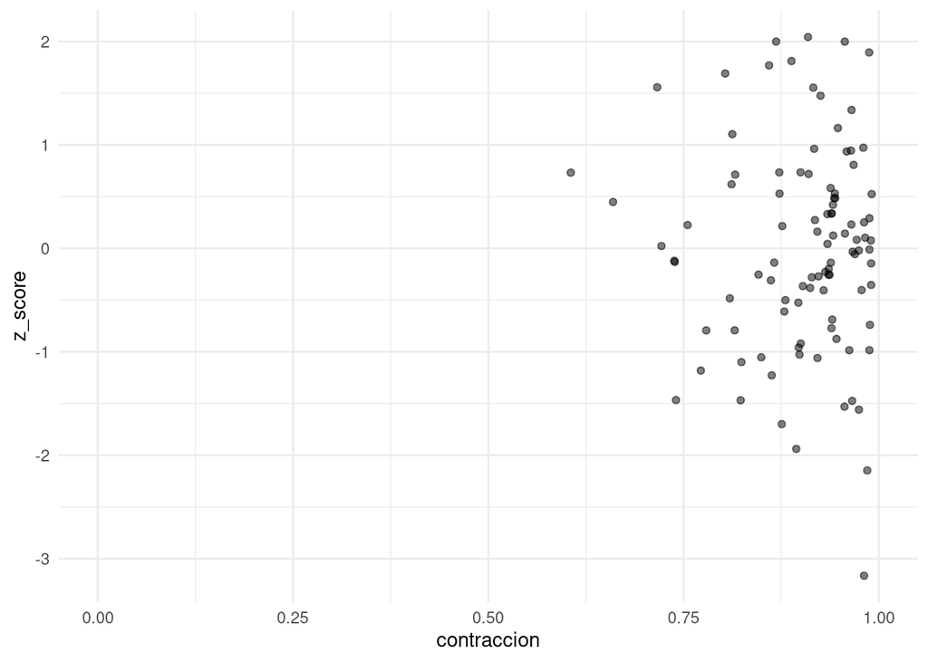

```r
ggplot(calib_inf, aes(x = contraccion, y = z_score)) + geom_point(alpha = 0.5) +
  xlim(c(0, 1))
```

### Ajuste a las observaciones

```r
set.seed(20021)
y_1 <- filter(lattice::singer, voice.part %in% c("Tenor 1", "Tenor 2")) %>%
    sample_n(20) %>%
  mutate(estatura = 2.54 * height) %>% pull(estatura)
y_2 <- filter(lattice::singer, voice.part %in% c("Bass 1", "Bass 2")) %>%
  sample_n(10) %>%
    mutate(estatura = 2.54 * height) %>% pull(estatura)

datos <- c(sim_ensemble_datos, list("y_1" = y_1,
                                    "y_2" = y_2))
datos$n_1 <- 20
datos$n_2 <- 10
ajuste <- modelo$sample(data = datos,
                          seed = 2210,
                          iter_sampling = 5000, iter_warmup = 1000,
                          refresh = 0,
                          show_messages = FALSE)
```

```
## Running MCMC with 4 sequential chains...
##
## Chain 1 finished in 0.1 seconds.
## Chain 2 finished in 0.1 seconds.
## Chain 3 finished in 0.1 seconds.
## Chain 4 finished in 0.1 seconds.
##
## All 4 chains finished successfully.
## Mean chain execution time: 0.1 seconds.
## Total execution time: 0.8 seconds.
```

```r
ajuste
```

```
##  variable   mean median   sd  mad     q5    q95 rhat ess_bulk ess_tail
##  lp__     -74.06 -73.71 1.47 1.26 -76.97 -72.36 1.00     8992    11064
##  mu[1]    175.36 175.38 1.66 1.64 172.60 178.05 1.00    16016    13244
##  mu[2]    180.32 180.47 1.94 1.79 176.93 183.18 1.00    14377    10123
##  sigma[1]   5.81   5.66 1.26 1.20   4.03   8.13 1.00    18690    14435
##  sigma[2]   4.00   3.72 1.60 1.40   1.97   7.01 1.00    15272    13590
##  dif       -4.97  -5.03 2.55 2.48  -8.99  -0.64 1.00    13830    10619
##  mayor_1    0.03   0.00 0.18 0.00   0.00   0.00 1.00    11363    11363
```

Checamos el resumen que nos interesa:

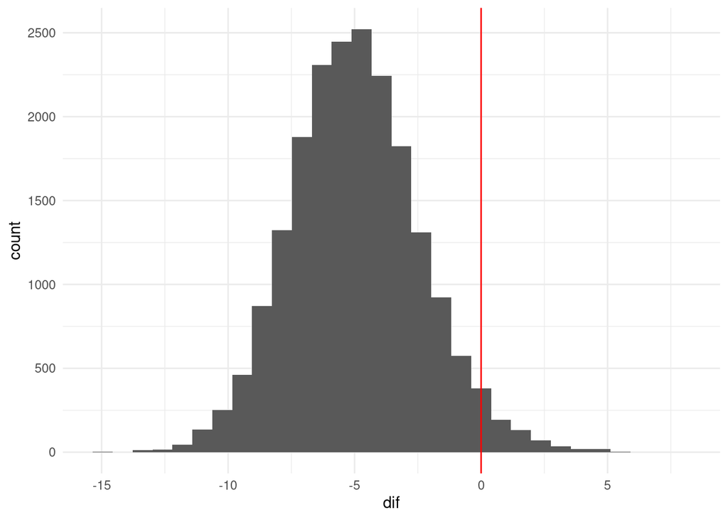

```r
sims_dif <- ajuste$draws("dif") %>% as_draws_df() %>% as_tibble()
ggplot(sims_dif, aes(x = dif)) + geom_histogram() +
  geom_vline(xintercept = 0, colour = "red")
```

Y vemos que tenemos alguna evidencia de que los bajos tienen mayor estatura que los tenores. La con alta probabilidad la diferencia va de 1 a 9 centímetros de diferencia.

### Verificación posterior dentro de muestra

```bash
sed -n '/^generated/,/\}/p' stan/modelo.stan
```

```
## generated quantities {
##
## }
```